# PDE Model Calibration using MEP-LINCS data

Last update: 25 August, 2020

# 1 Pre-requisites

Load all required libraries and define static variables:

```r
library(moments)
library(plotly)
library(transport)
library(aqfig)
library(sensitivity)
library(ggplot2)
library(scatterplot3d)
library(data.table)
library(matlab)
library(factoextra)
library(RColorBrewer)
library(FactoMineR)
library(umap)
library(dbscan)
library(plyr)
library(ggpubr)
source("Utils.R")
UM_SPOT_DIAM = 350
hcc1954_DT = 43.81; ##hrs
##Summary stats of interest
soi =  as.character(unique(round((1:175)/17)*17));
poi_nondim = c("phi_u","xi_u","eta", "a", "R", "L", "tau", "u0")
poi_dim = c("Chi", "gamma", "delta", "xi_u", "phi_u")
##ECMs of interest
eoi = c("GAP43", "CDH1");
PARAM_ANNO = PARAM_ANNOTATION(numberOfSubpopulations=1)
print(head(PARAM_ANNO), quote = F)
```

```
## $tFinal
## [1] Max final time to run the simulation to
##
## $R
## [1] Radius of the dish
##
## $R_tilde
## [1] Radius of the dish
##
## $R0
## [1] Initial seeding radius
##
## $tau
## [1] Simulation time
##
## $L
## [1] Characteristic length
```

# 2 Ranking simulations

For model calibration we use data from the microenvironment microarray (MEMA) platform (Watson et al., 2018; Kenan et al., 2018). It consists of extra-cellular matrix (ECM) spots, 350 um in diameter, that are printed onto a rectangular array. Advantage of using this data for model calibration is for one the amount of data available: 48 environments – defined by 48 distinct ECM coats – and we have multiple replicates of each adding up to a total of close to 700 spots on this array. Another advantage is that it is a very controlled expderiment: cells are grown for exactly 3 days. And we’re looking at a ductal breast carcinoma cell line called HCC1954, which has a doubling time of 44 hours, translating to maximal growth rate of 0.56 per day. We know the seeding radius is simply the radius of a single MEMA spot. So we have 5 parameters left that we need to fit to the data. And to do so we ran more than 150,000 simulations throughout the parameter search space. Here we read both sets of summary statistics, obtained from simulated and experimental data:

```r
## Read simulated summary statistics
allStats = read.table("SupplementaryData1.txt", sep="\t", check.names = F, stringsAsFactors = F, row.names = NULL);
param = read.table("SupplementaryData2.txt", sep="\t", check.names = F, stringsAsFactors = F, header=T, row.names = 1);
param$percentV0 = 100*param$v0/param$uv0
sumstats = allStats[grep("u+v",allStats$row.names, fixed = T), ]
sumstats = sumstats[!param$FAIL,]
param    =    param[!param$FAIL,]
rownames(sumstats) <- sumstats$simulation
sumstats = sumstats[,colnames(sumstats) %in% soi, drop=F]

## Read observed summary statistics
mepStats = read.table("SupplementaryData3.txt", sep="\t", check.names = F, stringsAsFactors = F)
mepStats = mepStats[,colnames(mepStats) %in% colnames(sumstats), drop=F]

## Infer dimensional from non-dimensional parameters:
param_dim = t(apply(param[,c("eta","a","R", "tau")], 1, function(x) nondimensional2dimensional(eta=x["eta"], a = x["a"], R = x["R"], tau = x["tau"])))
param = cbind(param,param_dim)
print(head(param),quote = F)
```

```
##        xi_u xi_v      phi_u phi_v        u0 v0       uv0        eta
## 1  90.32105    0 1.70445113     0 0.3628259  0 0.3628259  4.7612677
## 3 145.53456    0 1.57538574     0 0.3628259  0 0.3628259 19.6664202
## 5  54.46008    0 0.08533179     0 0.3628259  0 0.3628259  3.2880533
## 6 248.39577    0 1.25018921     0 0.3628259  0 0.3628259  2.1899059
## 7 191.99604    0 2.88532795     0 0.3628259  0 0.3628259  7.8798778
## 8  10.37042    0 2.74531682     0 0.3628259  0 0.3628259  0.3060404
##           a      tau         R tFinal        R0         dt         dr
## 1  41.31542 1.692958  7.059692      2 0.7059692 0.03908803 0.03908803
## 3  59.04220 1.692958 14.867154      2 1.4867154 0.05398309 0.05398309
## 5  47.06599 1.692958 14.401273      2 1.4401273 0.05334633 0.05334633
## 6  63.00579 1.692958  4.573648      2 0.4573648 0.03040622 0.03040622
## 7 107.19451 1.692958  9.444674      2 0.9444674 0.04490902 0.04490902
## 8  38.76447 1.692958  6.784610      2 0.6784610 0.03829314 0.03829314
##    FAIL percentV0    lambda        L T       Chi     gamma    delta
## 1 FALSE         0 0.5643192 247.8862 3 34676.030 165101.86 23.31509
## 3 FALSE         0 0.5643192 117.7091 3  7818.893 153769.63 33.31865
## 5 FALSE         0 0.5643192 121.5170 3  8332.958  27399.21 26.56024
## 6 FALSE         0 0.5643192 382.6267 3 82618.149 180925.97 35.55537
## 7 FALSE         0 0.5643192 185.2896 3 19374.342 152667.45 60.49192
## 8 FALSE         0 0.5643192 257.9367 3 37544.914  11490.26 21.87553
```

Next we calculate spatial summary statistics that are independent of the calibration data (i.e. the growth patterns on the ECMs). We include four additional spatial statistics: skewness, kurtosis, confluence and gradient near the edge of the ECM.

```r
## Kurtosis, skewness & confluence:
sumstats2 = cbind(apply(sumstats, 1, moments::kurtosis), apply(sumstats, 1, moments::skewness))
sumstats2 = as.data.frame(sumstats2)
rownames(sumstats2) = rownames(sumstats)
colnames(sumstats2) = c("kurtosis","skewness")
sumstats2$confluence = apply(sumstats,1,mean)

## Distance to center of circular domain:
d2c = as.numeric(colnames(mepStats))
## Sharpness near boundary of circular domain:
ii = (length(d2c)-4):length(d2c)
sumstats2$coef = apply(sumstats, 1, function(x) summary(lm(x[ii] ~ d2c[ii]))$coefficients[2,"Estimate"] )
```

We compare 1D spatial distributions obtained from each simulation with each observation from the 48 ECM environments using the Wasserstein metric.

```r
d = apply(mepStats[,colnames(sumstats)], 1, function(x) apply(sumstats, 1, function(y) wasserstein1d(x, y)));
ii_sim = apply(d, 2, function(x) which(x<=quantile(d, 0.0005, na.rm = T)));
col = fliplr(brewer.pal(12, "Paired"))
names(col) = names(ii_sim)[sort(sapply(ii_sim, length), index.return=T, decreasing = T)$ix[1:length(col)]]
col["prior"] = "gray"
print(paste(ncol(d)-length(col),"ECMs account for",1-length(unlist(ii_sim[names(col)]))/length(unlist(ii_sim))," of top simulations. Excluded from further analsysis"), quote=F)
```

```
## [1] 34 ECMs account for 0.0155038759689923  of top simulations. Excluded from further analsysis
```

```r
ii_sim = ii_sim[names(ii_sim) %in% names(col)]
print(paste("Focusing on the remaining",length(ii_sim),"ECMs, represented by",length(unlist(ii_sim)),"simulations."), quote=F)
```

```
## [1] Focusing on the remaining 12 ECMs, represented by 3429 simulations.
```

## 2.1 Visualization

Posterior distributions of dimensional parameters from the top 2% simulations differ from the prior uniform distribution (in gray). This was the case for 12 out of 48 ECMs, suggesting the model could explain one quarter of growth conditions on the MEMA platform. Not only do they differ from the prior, but they are also distinct for different ECMs:

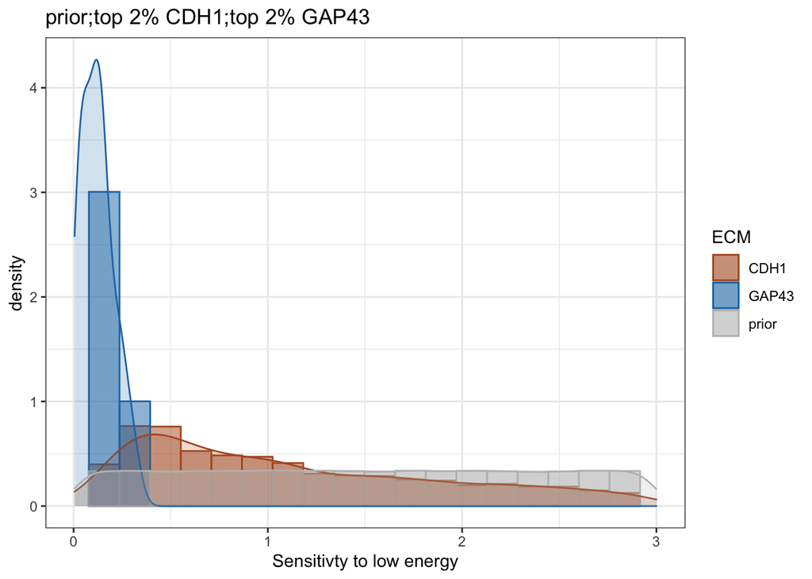

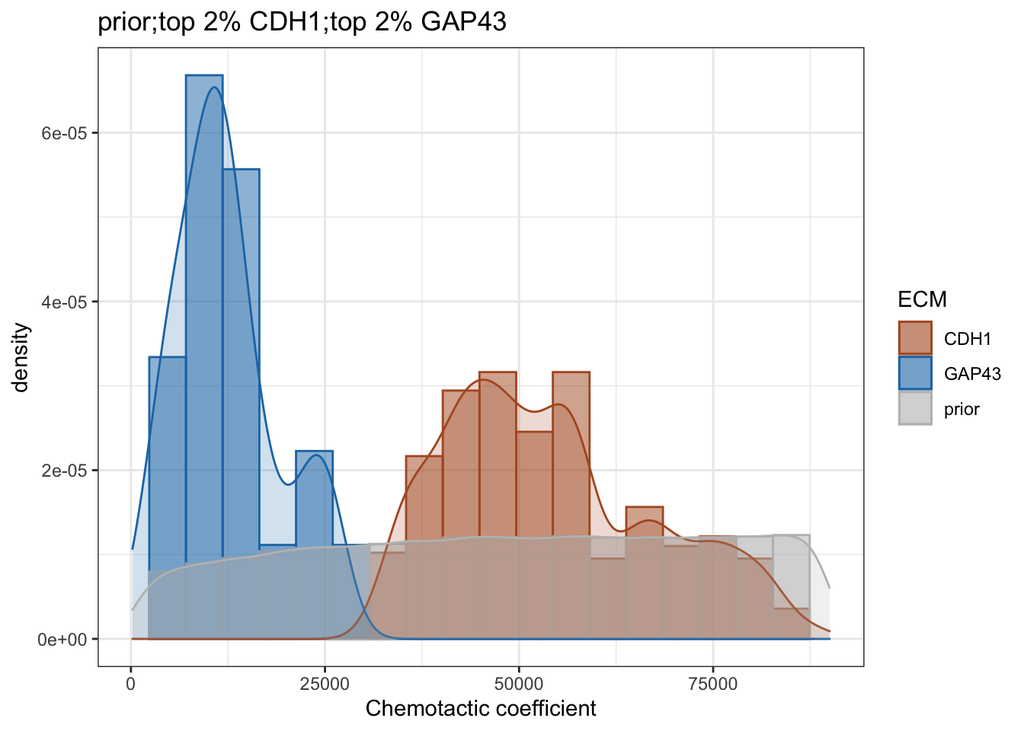

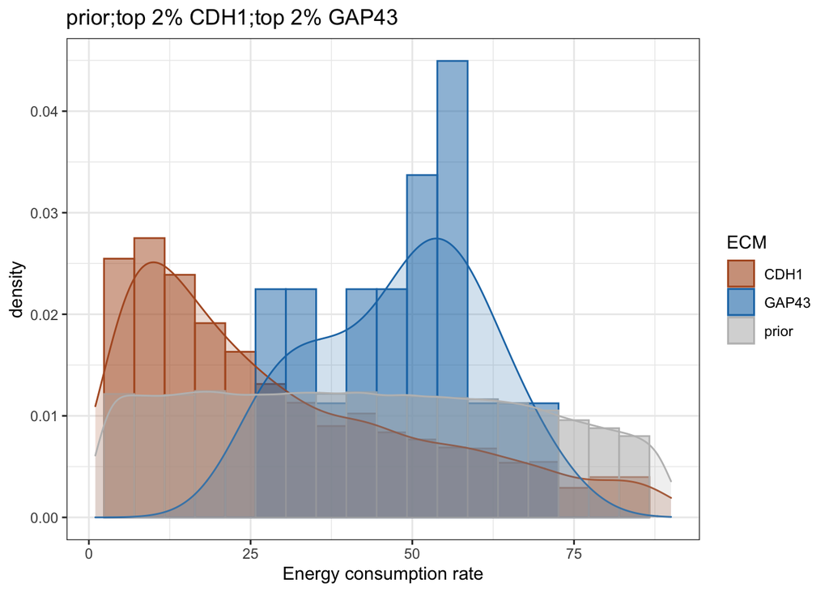

```r
param$group <-  as.character(paste0("top ",round(100*length(unique(unlist(ii_sim)))/nrow(param)),"%"))
param$ECM <- "prior"
param_2 = rbind(param, param[unlist(ii_sim),] )
param_2$group[1:nrow(param)] = "prior"
idx = (nrow(param)+1):nrow(param_2)
param_2$ECM[idx] <- unlist(sapply(names(ii_sim), function(x) rep(x,length(ii_sim[[x]]))))
param_2$group[idx] = paste(param_2$group[idx], param_2$ECM[idx])

lapply(c("phi_u","Chi","delta"), function(x) ggplotHist(x, param_2[param_2$ECM %in% c(eoi, "prior"), ], logx=F, col = col[unique(param_2$ECM)]))
```

# 3 Sensitivity analysis

The Sobol Index quantifies how much of the variability in spatial cell concentration is explained by each parameter:

```r
sensi = list()
sub_breaks = seq(1,nrow(param),by=10000)
for (i in 2:length(sub_breaks)){
  print(paste("Calculating Sobol index for simulation set", (i-1),"of",(length(sub_breaks)-1) ), quote=F)
  for(ecm in colnames(sumstats2)){
    goorgrow <- function( param){
      return(sumstats2[rownames(param),ecm])
    }
    x <- sobolshap_knn(model = goorgrow, X = param[sub_breaks[(i-1)]:sub_breaks[i],poi_dim], U = NULL, method = "knn", n.knn = 5, return.shap = TRUE, rescale = TRUE, n.limit = 2000)
    sensi[[ecm]][[i-1]] = x
  }
}
```

```
## [1] Calculating Sobol index for simulation set 1 of 14
## [1] Calculating Sobol index for simulation set 2 of 14
## [1] Calculating Sobol index for simulation set 3 of 14
## [1] Calculating Sobol index for simulation set 4 of 14
## [1] Calculating Sobol index for simulation set 5 of 14
## [1] Calculating Sobol index for simulation set 6 of 14
## [1] Calculating Sobol index for simulation set 7 of 14
## [1] Calculating Sobol index for simulation set 8 of 14
## [1] Calculating Sobol index for simulation set 9 of 14
## [1] Calculating Sobol index for simulation set 10 of 14
## [1] Calculating Sobol index for simulation set 11 of 14
## [1] Calculating Sobol index for simulation set 12 of 14
## [1] Calculating Sobol index for simulation set 13 of 14
## [1] Calculating Sobol index for simulation set 14 of 14
```

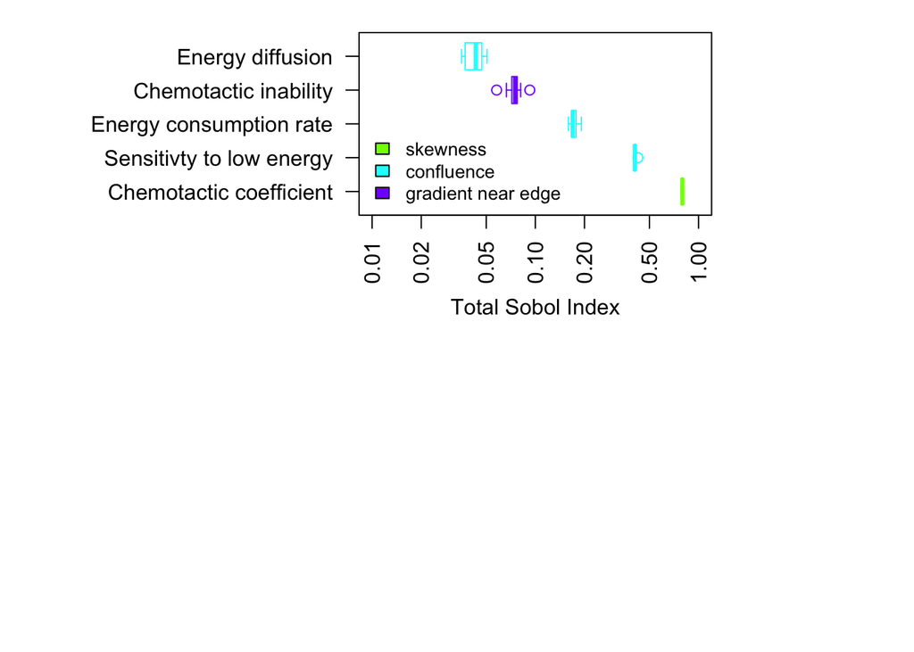

```r
sobol = lapply(names(sensi), function(ecm) lapply(sensi[[ecm]], function(x) extract(x)$T ))
sobol = lapply(sobol, function(x) do.call(rbind, x))
names(sobol) = names(sensi)

ii = c("skewness","confluence","confluence","coef","confluence")
names(ii) = colnames(sobol[[1]])
ii = ii[c("Chi", "phi_u", "delta", "xi_u", "gamma" )]
senscol = rainbow(length(sobol)); names(senscol) = names(sobol)

## Display which spatial feature is best explained by each parameter:
par(mfrow=c(2,1), mai=c(0.85,2.75,0.25,1.55))
boxplot(t(do.call(rbind,lapply(names(ii), function(x) sobol[[ii[x] ]][,x]))), ylim=c(0.01,1), border = senscol[ii], xlab = "Total Sobol Index", names = PARAM_ANNO[names(ii)], las=2, horizontal =T, log="x")
lines(c(0,100), c(0,0), lty=2);
legend("bottomleft", gsub("coef","gradient near edge", unique(ii)), fill=senscol[unique(ii)], cex=0.85, bty="n")
```

## 3.1 ECM specific model parameters

Next, top simulations were projected onto UMAP space, revealing three clusters.

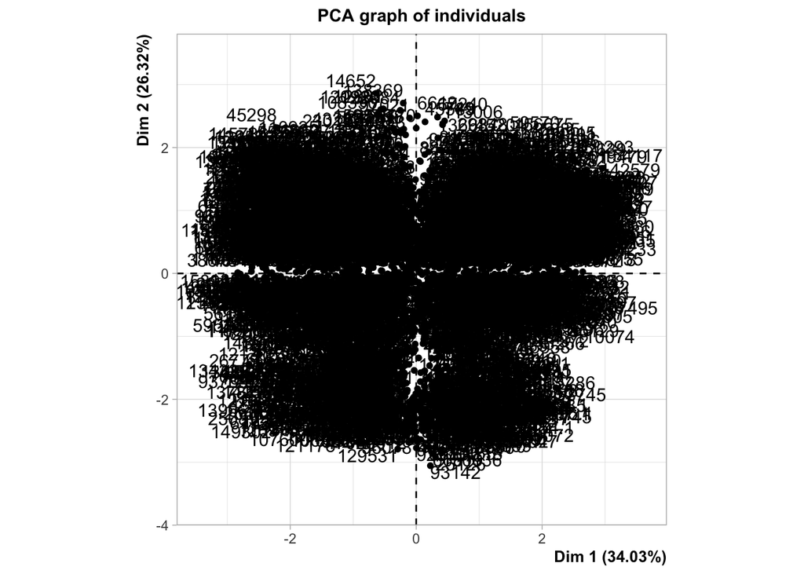

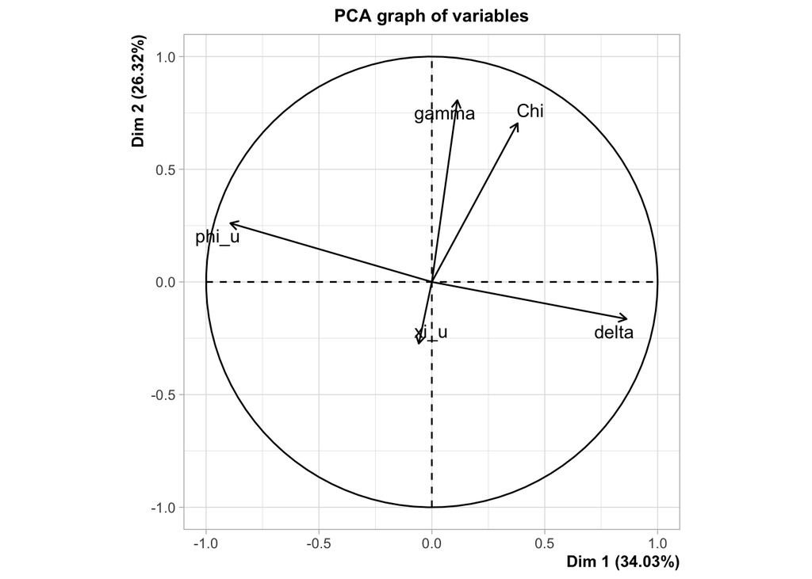

```r
pca <- FactoMineR::PCA(param[unlist(ii_sim),poi_dim], graph = T,scale.unit = T)
```

```r
print(factoextra::get_eigenvalue(pca)[,"variance.percent"], quote=F)
```

```
##     Dim.1     Dim.2     Dim.3     Dim.4     Dim.5
## 34.027824 26.315989 20.417118 15.061628  4.177441
```

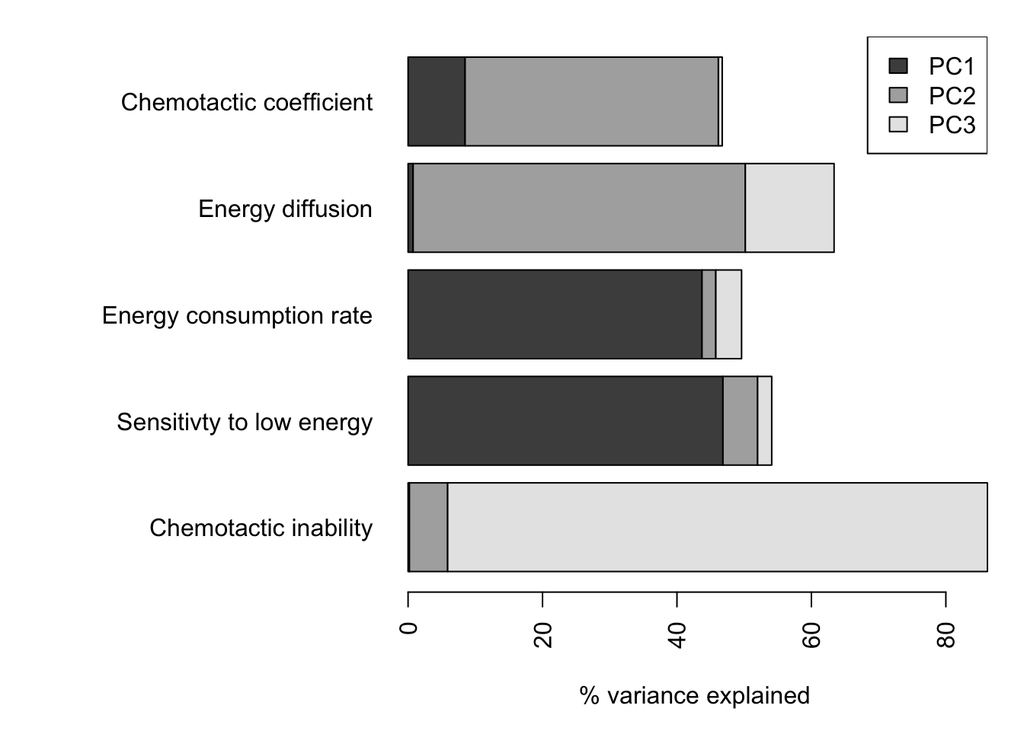

```r
pct_explained = sweep(pca$var$contrib, 2, FUN="*", factoextra::get_eigenvalue(pca)[,"variance.percent"]/100)
pct_explained = apply(pct_explained[,1:3], 1, sum);
pct_explained = pct_explained[names(sort(pct_explained, decreasing = T))]
par(mai=c(0.95,2.75,0.25,0.25))
barplot(t(pca$var$contrib[names(pct_explained),1:3]), names=PARAM_ANNO[names(pct_explained)], las=2, beside = F, horiz = T, xlab="% variance explained");
legend("topright", c("PC1", "PC2", "PC3"), fill = gray.colors(3) )
```

```r
## UMAP
ump = as.data.frame(umap::umap(pca$ind$coord)$layout)
colnames(ump) = c("UMAP 1", "UMAP 2")
ump$ecm = unlist(sapply(names(ii_sim), function(x) rep(x,length(ii_sim[[x]]))))
```

Most ECMs were enriched in one single of the three clusters. All five model parameters show significant differences between the three clusters – for example ECMs in the darkest cluster tend to have higher nutrient diffusion coefficients:

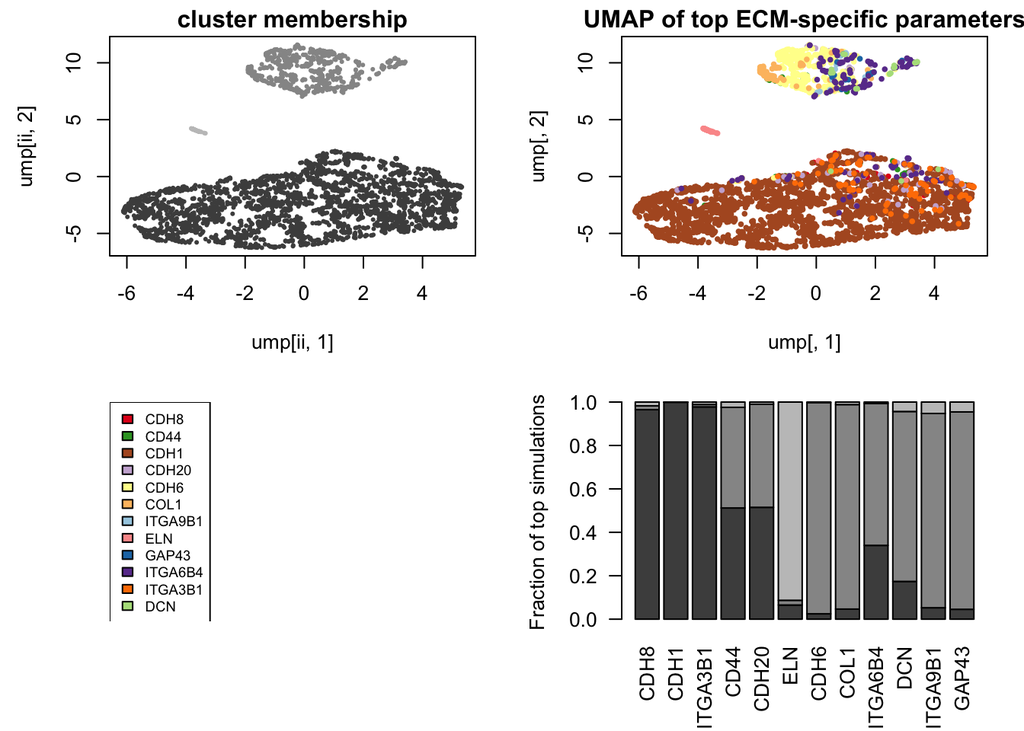

```r
par(mfrow=c(2,2), mai=c(0.75,0.75,0.25,0.25))
clusters = dbscan::dbscan(ump[,1:2],eps=0.8, minPts = 18)$cluster ;
names(clusters) = ump$ecm
clcol = gray.colors(length(unique(clusters))+1)
fr = plyr::count(clusters)
ii = which(clusters %in% fr$x[fr$freq>1])

## Display clusters:
plot(ump[ii,1],ump[ii,2], col=clcol[clusters[ii]], pch=20, main="cluster membership",cex=0.5)
plot(ump[,1],ump[,2], pch=20, col=col[ump$ecm], cex=0.7, main="UMAP of top ECM-specific parameters")
plot(1,col="white", axes=F, xlab="", ylab="")
legend("topleft", unique(names(clusters)), fill=col[unique(names(clusters))], cex=0.7)

## Cluster membership distribution per ECM
la = lapply(unique(names(clusters)), function(x) plyr::count(c(unique(clusters[ii]),clusters[ii][names(clusters[ii])==x])))
la = sapply(la, function(x) x$freq/sum(x$freq))
colnames(la) = unique(names(clusters))
la = la[,sort(apply(la,2, function(x) mean(rank(x)[1:2])), index.return=T)$ix]
la = la[,sort(apply(la,2, function(x) mean(rank(x)[2:3])), index.return=T)$ix];
barplot(la, las=2, col = clcol, ylab="Fraction of top simulations")
```

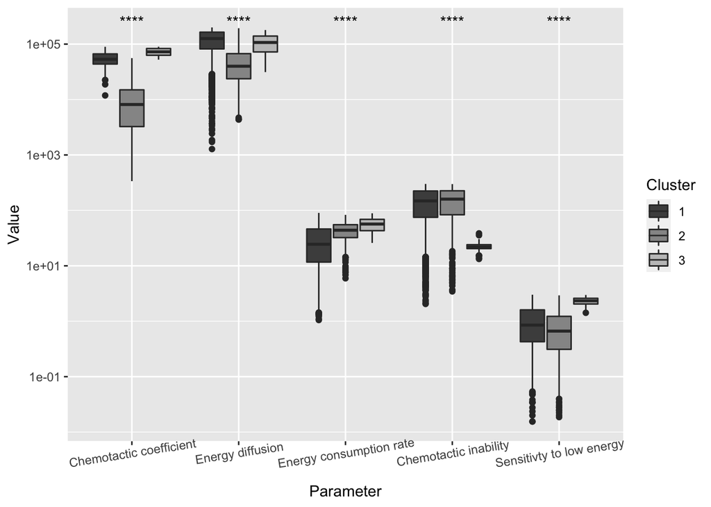

```r
plot(1, col="white")
legend("topleft", paste("cluster",1:nrow(la)), fill=clcol)

## Inter-cluster comparison of model parameters:
tmp=pca$call$X;
tmp = lapply(colnames(tmp), function(x) cbind(as.data.frame(0.01+tmp[,x,drop=F]),as.factor(clusters), rep(PARAM_ANNO[[x]],nrow(tmp))))
tmp = as.data.frame(rbindlist(tmp, use.names=F))
colnames(tmp) = c("Value","Cluster","Parameter")
ggplot(tmp, aes(x=Parameter, y=Value, fill=Cluster)) + geom_boxplot() +  scale_y_log10() +
  scale_fill_manual(values=clcol) + theme(axis.text.x = element_text(angle = 9)) +
  ggpubr::stat_compare_means(aes(group = Cluster), label = "p.signif", method="anova")
```

We conclude that there is little redundancy in the contributions of model paramters and that all play a role in explaining different aspects of the cells’ growth patterns.